# Wendel_explore_time

Wendel Raymond

January 9, 2018

# Accounting for time

Exploratory analysis has indicated that there is a temporal signal in pretty much all of our data. Some measures appear to be more sensitive to time than other. Here I will explore options for accounting of time statistically so that we can run linear models.

We will we using the eelgrass transect data to explore strategies to dealing with time. However, other data, in different files, will also need to be screened for temporal effects. After some research and consultation, there are 3 (kinda 4) ways to account for time in our models. In general “time” should be included directly in the statistical model. Yes, using the residuals is another option but there is no statistical benefit of doing that. It will actually be more time consuming because we will have to run a regression of response ~ time, then extract the residuals, and then run another test. This also increases out total number to test that we will run. So, models should take the general form of $y=\alpha + time + sea otter + other...$. Within this general model framework there are 3 ways to paramaterize time which I are explored below. They are.

1. Time as a continuous variable $y=\alpha + time + sea otter + other...$. Time will essentially just be Julian day and assumed to relate linearly to y.
2. Time as a categorical variable $y=\alpha + \delta_t +sea otter + other...$. Due to our sampling design we can group sites into 4 discrete sampling windows. If we go this direction one may think (as I did) that using a mixed effects model with a random effect of time $y=\alpha + sea otter + other... + a_t$ where $a_t$ is the random intercept of time. Well, after more consideration and consultation this is likely not appropriate. Reason 1) is that we don’t have the best temporal replication for this approach and more importantly 2) we have to assume that when we sampled a site was “randomly drawn from the population” which its not really. Everything happened in the same season.
3. Time as a smooth function $y=\alpha + s(time) + sea otter + other...$. This would be a semi-parametric GAM model where time is modeled non-parametrically but the other factors would be modeled parametrically. Now, I know what you are thinking, GAMs are kinda BS, but we can easily constrain the fitting of smooth time function to something relatively simple, biologically realistic and therefore reasonably interpretable (k <= 4 in gam() function of mgcv package).

Lets look at some example data so that we can think about things.

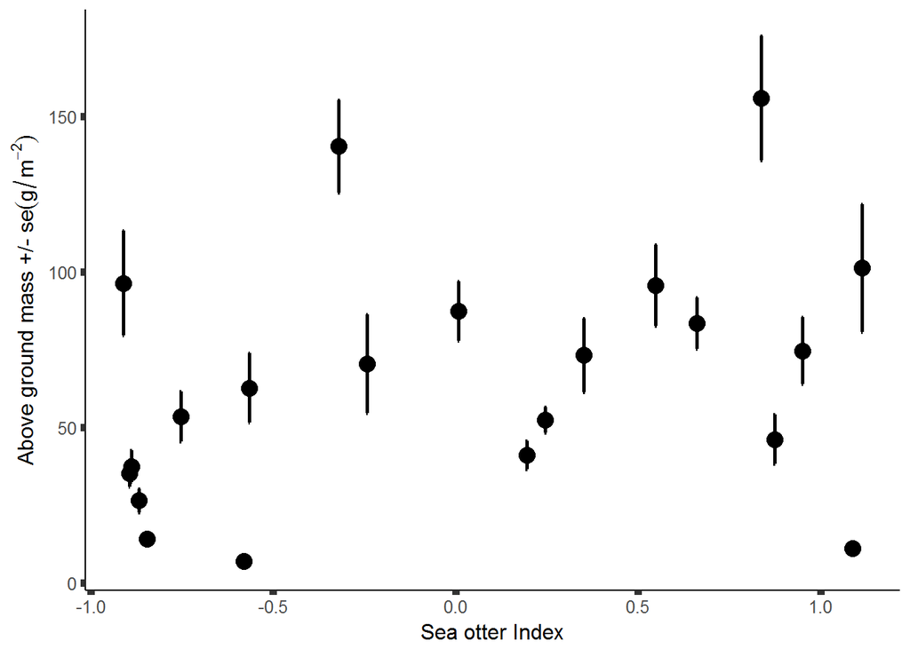

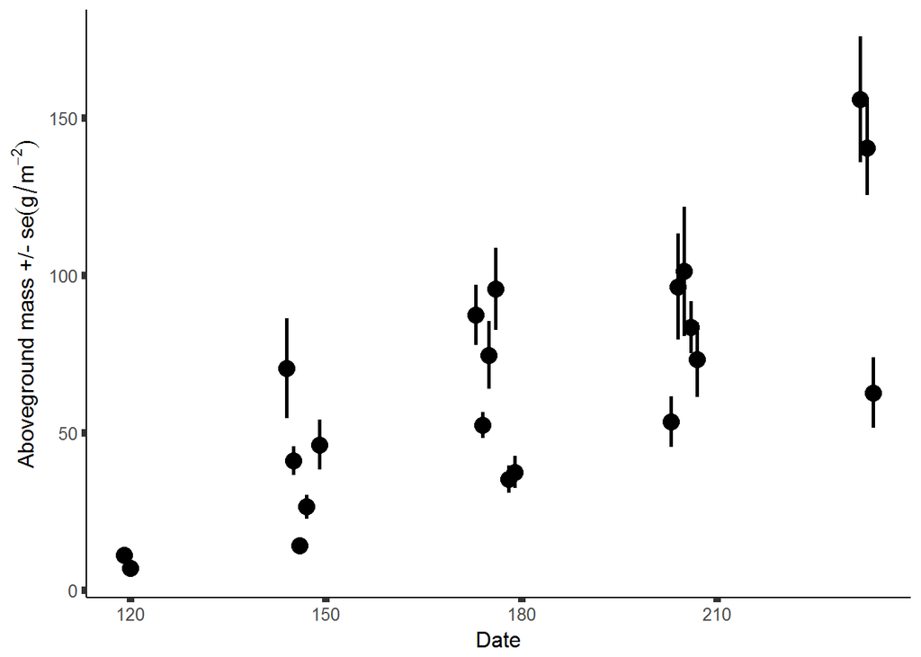

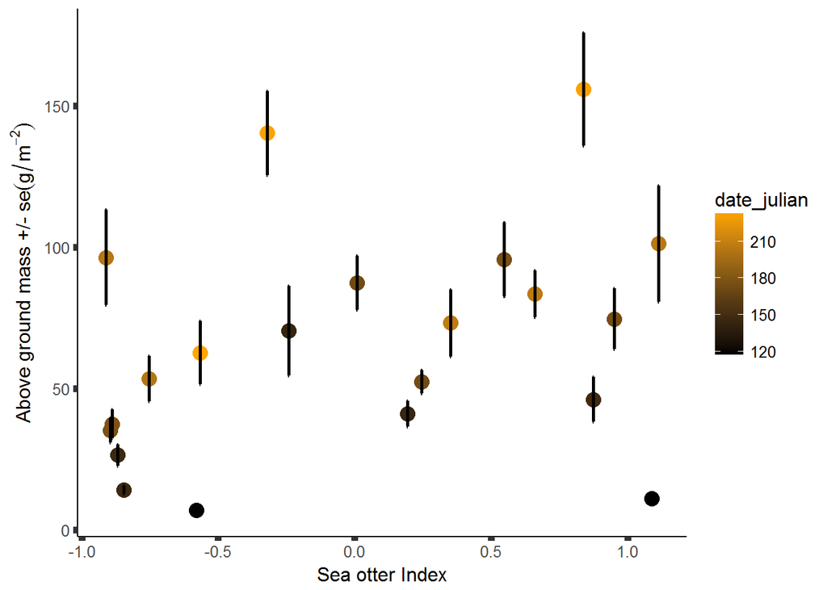

## Option 1 - time as continuous

Exploration of parameterizing time as continuous variable.

```
##
## Call:
## lm(formula = abvgnd_mass ~ sea_otter_index, data = eg.dat)
##
## Residuals:
##     Min      1Q  Median      3Q     Max
## -72.902 -23.448   1.621  16.774  80.944
##
## Coefficients:
##                 Estimate Std. Error t value Pr(>|t|)
## (Intercept)       65.013      8.393   7.746  2.7e-07 ***
## sea_otter_index   17.441     11.582   1.506    0.149
## ---
## Signif. codes:  0 '***' 0.001 '**' 0.01 '*' 0.05 '.' 0.1 ' ' 1
##
## Residual standard error: 38.46 on 19 degrees of freedom
## Multiple R-squared:  0.1066, Adjusted R-squared:  0.0596
## F-statistic: 2.268 on 1 and 19 DF,  p-value: 0.1486
```

```
##
## Call:
## lm(formula = abvgnd_mass ~ date_julian, data = eg.dat)
##
## Residuals:
##     Min      1Q  Median      3Q     Max
## -50.718 -16.678  -2.007  13.105  44.274
##
## Coefficients:
##             Estimate Std. Error t value Pr(>|t|)
## (Intercept) -90.6921    29.8781  -3.035  0.00681 **
## date_julian   0.8722     0.1644   5.307 4.03e-05 ***
## ---
## Signif. codes:  0 '***' 0.001 '**' 0.01 '*' 0.05 '.' 0.1 ' ' 1
##
## Residual standard error: 25.83 on 19 degrees of freedom
## Multiple R-squared:  0.5971, Adjusted R-squared:  0.5759
## F-statistic: 28.16 on 1 and 19 DF,  p-value: 4.026e-05
```

```
##
## Call:
## lm(formula = abvgnd_mass ~ sea_otter_index * date_julian, data = eg.dat)
##
## Residuals:
##     Min      1Q  Median      3Q     Max
## -32.857 -13.918  -5.492  20.284  38.235
##
## Coefficients:
##                             Estimate Std. Error t value Pr(>|t|)
## (Intercept)                 -88.2440    26.4103  -3.341  0.00387 **
## sea_otter_index             -23.2562    35.8939  -0.648  0.52569
## date_julian                   0.8581     0.1453   5.905 1.73e-05 ***
## sea_otter_index:date_julian   0.2279     0.1997   1.141  0.26965
## ---
## Signif. codes:  0 '***' 0.001 '**' 0.01 '*' 0.05 '.' 0.1 ' ' 1
##
## Residual standard error: 22.79 on 17 degrees of freedom
## Multiple R-squared:  0.7193, Adjusted R-squared:  0.6697
## F-statistic: 14.52 on 3 and 17 DF,  p-value: 6.071e-05
```

Lets compare the models. Remember, lets focus on how the models preform, rather than what coefficients are significant. Ok so Model 1.3 which includes sea otters and time has the best fit. Of course more parameters will make a model fit better but when you compare it to Models 1.1 and 1.3 you can see the incremental increase.

|  | Model | Rsq | F | df_1 | df_2 |
| --- | --- | --- | --- | --- | --- |
| 1 | Mod 1.1 | 0.06 | 2.27 | 1 | 19 |
| 2 | Mod 1.2 | 0.58 | 28.16 | 1 | 19 |
| 3 | Mod 1.3 | 0.67 | 14.52 | 3 | 17 |

## Option 2 - time as a 4 level factor

Exploration of parameterizing time as a 4 factor variable. At least for this example I am going to omit the two April sites and then classify each site to 4 time levels that essentially align with month of sampling.

Various models. Again, the mixed effects approach here is likely not appropriate. However, I included it here just to see. So what is interesting here is that sea otter index becomes significant when time is included as a factor (mod2.2), demonstrating that time is mopping up variability.

```
## Analysis of Variance Table
##
## Response: abvgnd_mass
##           Df Sum Sq Mean Sq F value   Pr(>F)
## date_bin   3  12901  4300.2  5.5551 0.009103 **
## Residuals 15  11612   774.1
## ---
## Signif. codes:  0 '***' 0.001 '**' 0.01 '*' 0.05 '.' 0.1 ' ' 1
```

```
## Analysis of Variance Table
##
## Response: abvgnd_mass
##                          Df  Sum Sq Mean Sq F value   Pr(>F)
## sea_otter_index           1  5109.3  5109.3  9.0826 0.011787 *
## date_bin                  3 11655.8  3885.3  6.9067 0.007002 **
## sea_otter_index:date_bin  3  1559.4   519.8  0.9241 0.461267
## Residuals                11  6187.9   562.5
## ---
## Signif. codes:  0 '***' 0.001 '**' 0.01 '*' 0.05 '.' 0.1 ' ' 1
```

```
## Linear mixed-effects model fit by maximum likelihood
##  Data: eg.dat.redu
##       AIC      BIC    logLik
##   188.286 192.0638 -90.14302
##
## Random effects:
##  Formula: ~1 | date_bin
##         (Intercept) Residual
## StdDev:    24.85772 22.84345
##
## Fixed effects: abvgnd_mass ~ sea_otter_index
##                    Value Std.Error DF  t-value p-value
## (Intercept)     75.65472  14.32114 14 5.282729  0.0001
## sea_otter_index 20.80846   7.90541 14 2.632179  0.0197
##  Correlation:
##                 (Intr)
## sea_otter_index 0.015
##
## Standardized Within-Group Residuals:
##        Min         Q1        Med         Q3        Max
## -1.5672765 -0.5429302 -0.4102678  0.8916853  1.6101295
##
## Number of Observations: 19
## Number of Groups: 4
```

## Option 3 - time as a smooth function

Finally we can parameterize time as a smooth function and our other factors as linear predictors in a semi-parametric model. We will go back to using the full data set (all 21 sites)

```
##
## Family: gaussian
## Link function: identity
##
## Formula:
## abvgnd_mass ~ s(date_julian, k = 4)
##
## Parametric coefficients:
##             Estimate Std. Error t value Pr(>|t|)
## (Intercept)   65.013      5.636   11.54 5.04e-10 ***
## ---
## Signif. codes:  0 '***' 0.001 '**' 0.01 '*' 0.05 '.' 0.1 ' ' 1
##
## Approximate significance of smooth terms:
##                edf Ref.df     F  p-value
## s(date_julian)   1      1 28.16 2.61e-05 ***
## ---
## Signif. codes:  0 '***' 0.001 '**' 0.01 '*' 0.05 '.' 0.1 ' ' 1
##
## R-sq.(adj) =  0.576   Deviance explained = 59.7%
## GCV = 737.38  Scale est. = 667.15    n = 21
```

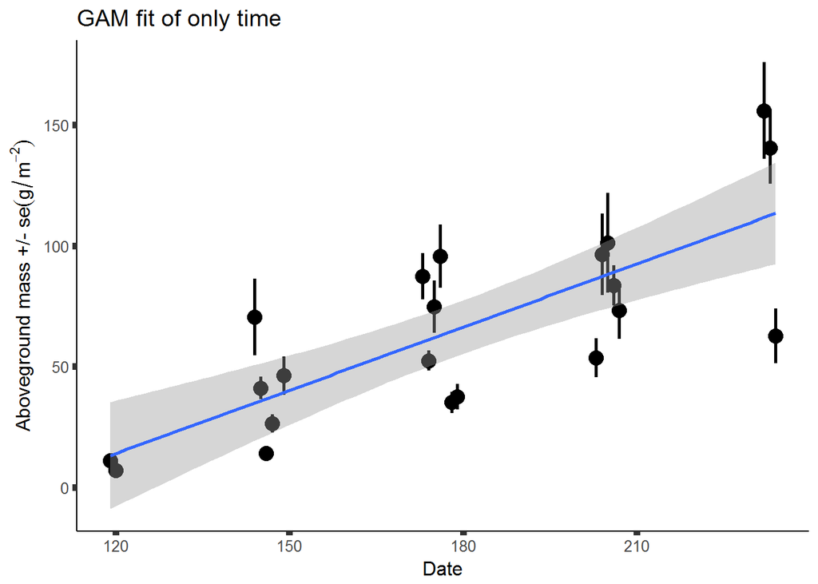

```
##
## Family: gaussian
## Link function: identity
##
## Formula:
## abvgnd_mass ~ sea_otter_index + s(date_julian, k = 4)
##
## Parametric coefficients:
##                 Estimate Std. Error t value Pr(>|t|)
## (Intercept)       65.013      5.016  12.962 1.44e-10 ***
## sea_otter_index   16.946      6.922   2.448   0.0248 *
## ---
## Signif. codes:  0 '***' 0.001 '**' 0.01 '*' 0.05 '.' 0.1 ' ' 1
##
## Approximate significance of smooth terms:
##                edf Ref.df    F  p-value
## s(date_julian)   1      1 35.2 5.99e-06 ***
## ---
## Signif. codes:  0 '***' 0.001 '**' 0.01 '*' 0.05 '.' 0.1 ' ' 1
##
## R-sq.(adj) =  0.664   Deviance explained = 69.8%
## GCV = 616.35  Scale est. = 528.3     n = 21
```

Lets compare models again. First a note, the deviance explained (Dev_Expln) parameter should be interpreted with some caution. It is the deviance explained with the intercept removed. What is important to note is that the equivalent degrees of freedom (Eq_df) for fitting time is only 1. This suggest a linear relationship for this comparison. Again, its not that surprising that the model with more parameters (Mod 3.2) has a better fit.

|  | Model | Rsq | Dev_Expln | Eq_df |
| --- | --- | --- | --- | --- |
| 1 | Mod 3.1 | 0.58 | 0.597 | 1 |
| 2 | Mod 3.2 | 0.66 | 0.698 | 1 |

## Thoughts

It looks like how we proceed will really depend on how we want to frame time as a factor in this part of the project. I think that a convincing argument could be made for any of these approaches. My initial thought have me leaning towards the semi-parametric GAM framework. While there is a concern that we may over-fit the data there are tools in place to help prevent that. Also, if our goal is really to test the effect of sea otters and other possible covariates we should account for time in the most robust and flexible way possible. GAMS can do that. The GAM approach may also lead to a more simplified overall analytical approach in that we can use the same model framework for all our analyses. While we have not explored this in detail yet, it is conceivable that time will not have a linear relationship with a response even after transformation. With the GAM that’s ok. If the relationship with time is a bit non-linear the GAM can deal with it and “soak up” that variability. Now, I am *not* suggesting that we brute force GAMs down everything. Graphical inspection and reviewing output of relationships will be important. If the equivalent degrees of freedom of the smooth function of time start getting >3ish we should rethink things.

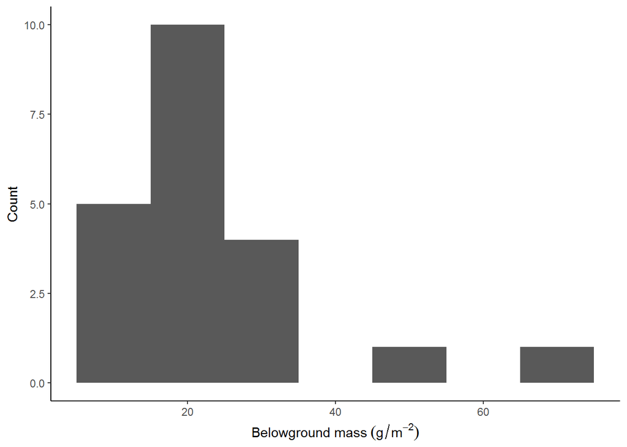

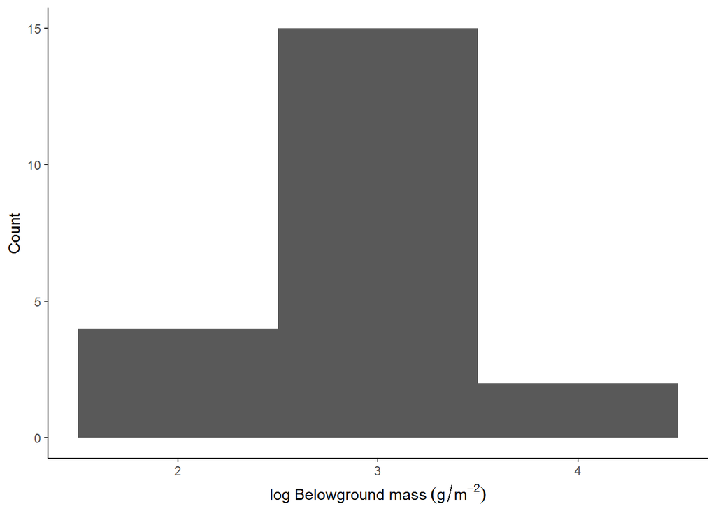

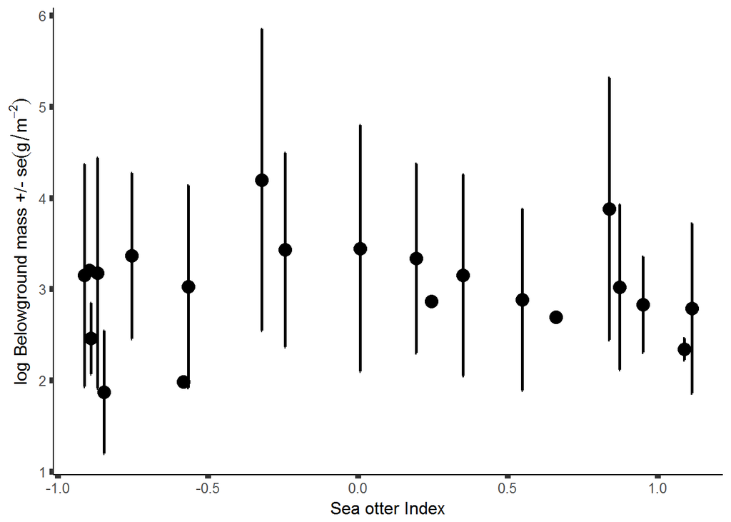

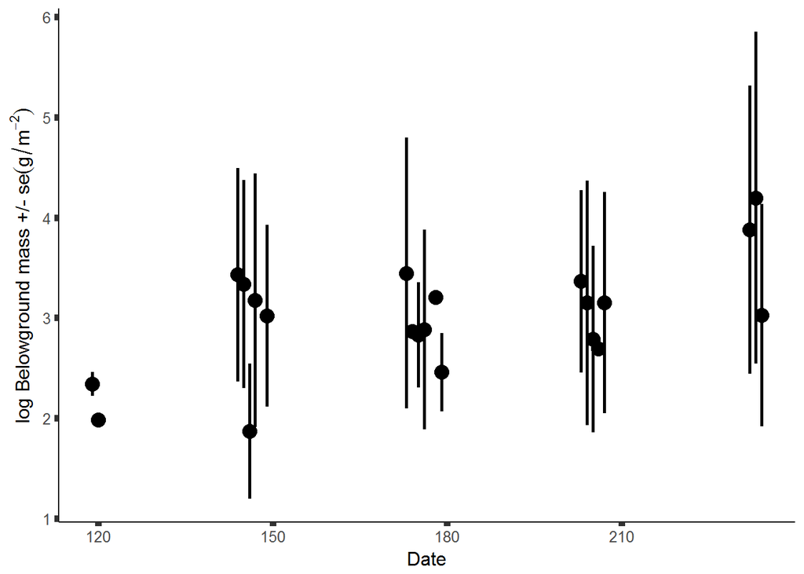

```
##
## Family: gaussian
## Link function: identity
##
## Formula:
## log(blwgnd_mass) ~ sea_otter_index
##
## Parametric coefficients:
##                 Estimate Std. Error t value Pr(>|t|)
## (Intercept)      3.00440    0.12448  24.136 1.02e-15 ***
## sea_otter_index  0.02154    0.17178   0.125    0.902
## ---
## Signif. codes:  0 '***' 0.001 '**' 0.01 '*' 0.05 '.' 0.1 ' ' 1
##
##
## R-sq.(adj) =  -0.0518   Deviance explained = 0.0827%
## GCV = 0.35966  Scale est. = 0.3254    n = 21
```

```
##
## Family: gaussian
## Link function: identity
##
## Formula:
## log(blwgnd_mass) ~ sea_otter_index + s(date_julian, k = 4)
##
## Parametric coefficients:
##                 Estimate Std. Error t value Pr(>|t|)
## (Intercept)      3.00440    0.10606  28.329   <2e-16 ***
## sea_otter_index  0.01649    0.14636   0.113    0.912
## ---
## Signif. codes:  0 '***' 0.001 '**' 0.01 '*' 0.05 '.' 0.1 ' ' 1
##
## Approximate significance of smooth terms:
##                edf Ref.df     F p-value
## s(date_julian)   1      1 8.175  0.0102 *
## ---
## Signif. codes:  0 '***' 0.001 '**' 0.01 '*' 0.05 '.' 0.1 ' ' 1
##
## R-sq.(adj) =  0.237   Deviance explained = 31.3%
## GCV = 0.27557  Scale est. = 0.2362    n = 21
```

```
##
## Call:
## lm(formula = log(blwgnd_mass) ~ sea_otter_index + date_julian,
##     data = eg.dat)
##
## Residuals:
##     Min      1Q  Median      3Q     Max
## -0.8330 -0.4575 -0.1032  0.3875  0.7340
##
## Coefficients:
##                 Estimate Std. Error t value Pr(>|t|)
## (Intercept)     1.425714   0.562230   2.536   0.0207 *
## sea_otter_index 0.016495   0.146363   0.113   0.9115
## date_julian     0.008843   0.003093   2.859   0.0104 *
## ---
## Signif. codes:  0 '***' 0.001 '**' 0.01 '*' 0.05 '.' 0.1 ' ' 1
##
## Residual standard error: 0.486 on 18 degrees of freedom
## Multiple R-squared:  0.3129, Adjusted R-squared:  0.2365
## F-statistic: 4.098 on 2 and 18 DF,  p-value: 0.03414
```

```
##
## Family: gaussian
## Link function: identity
##
## Formula:
## log(blwgnd_mass) ~ sea_otter_index + s(date_julian, k = 4)
##
## Parametric coefficients:
##                 Estimate Std. Error t value Pr(>|t|)
## (Intercept)      3.00440    0.10606  28.329   <2e-16 ***
## sea_otter_index  0.01649    0.14636   0.113    0.912
## ---
## Signif. codes:  0 '***' 0.001 '**' 0.01 '*' 0.05 '.' 0.1 ' ' 1
##
## Approximate significance of smooth terms:
##                edf Ref.df     F p-value
## s(date_julian)   1      1 8.175  0.0102 *
## ---
## Signif. codes:  0 '***' 0.001 '**' 0.01 '*' 0.05 '.' 0.1 ' ' 1
##
## R-sq.(adj) =  0.237   Deviance explained = 31.3%
## GCV = 0.27557  Scale est. = 0.2362    n = 21
```